# Bootstrap Geweke Diagnostic: An Introduction

Jay

2024-09-24

```r
library(bootGeweke)
```

# Introduction

This vignette demonstrates how to use the `bootstrap_geweke()` function from the **bootGeweke** package to perform a Geweke diagnostic with bootstrap sampling.

The Geweke diagnostic is a convergence diagnostic for Markov Chain Monte Carlo (MCMC) chains that introduced by John Geweke in 1992. It compares the means of the early and late portions of a single MCMC chain to detect any significant differences. If the chain has converged, the samples from the early and late segments should have similar means, implying that the chain is stationary and has reached equilibrium. The Geweke method calculates a Z-score to test the hypothesis that the means of these two segments are equal.

This package introduces a bootstrap approach to calculate Geweke Z-scores and confidence intervals of bootstrapping samples of the MCMC chain, to assess the convergence of the chain.

## Installing the Package

You can install the development version of the package using the provided file:

1. Locate the `bootGeweke_1.0.3.tar.gz` file, ensure that the package source `.tar.gz` file is in your working directory or specify the full path to the file.
2. Install the package using `install.packages()` as follow:

```r
install.packages("bootGeweke_1.0.3.tar.gz", repos = NULL, type = "source")
```

```r
library(bootGeweke)
# Check for vignettes
browseVignettes(package = "bootGeweke")
```

## Example of Using `bootstrap_geweke()` Function - Multiple Chains and Parameters

```r
library(bootGeweke)
library(coda)

# Simulate two parameters (mu and sigma) with three MCMC chains each
n_iter <- 1000  # Number of iterations per chain
n_chains <- 3   # Number of chains

# Create matrices for each chain, where each column represents a parameter
# First chain
chain1 <- cbind(mu = rnorm(n_iter, mean = 0, sd = 1),     # mu for chain 1
                sigma = rnorm(n_iter, mean = 2, sd = 0.5))  # sigma for chain 1

# Second chain
chain2 <- cbind(mu = rnorm(n_iter, mean = 0, sd = 1),     # mu for chain 2
                sigma = rnorm(n_iter, mean = 2, sd = 0.5))  # sigma for chain 2

# Third chain
chain3 <- cbind(mu = rnorm(n_iter, mean = 0, sd = 1),     # mu for chain 3
                sigma = rnorm(n_iter, mean = 2, sd = 0.5))  # sigma for chain 3

# Convert each chain to an mcmc object
mcmc_chain1 <- mcmc(chain1)
mcmc_chain2 <- mcmc(chain2)
mcmc_chain3 <- mcmc(chain3)

# Combine the chains into a single mcmc.list object
mcmc_object <- mcmc.list(mcmc_chain1, mcmc_chain2, mcmc_chain3)

# Perform the bootstrap Geweke diagnostic with multiple chains and parameters
# with default n as the length of the mcmc_object
result <- bootstrap_geweke(mcmc_object, B = 1000, confidence_level = 0.95,
                           frac1 = 0.1, frac2 = 0.5)
```

## Plotting the Z-scores

The `plot()` method for `bootGeweke` objects allow you to visualize the distribution of Z-scores for different parameters:

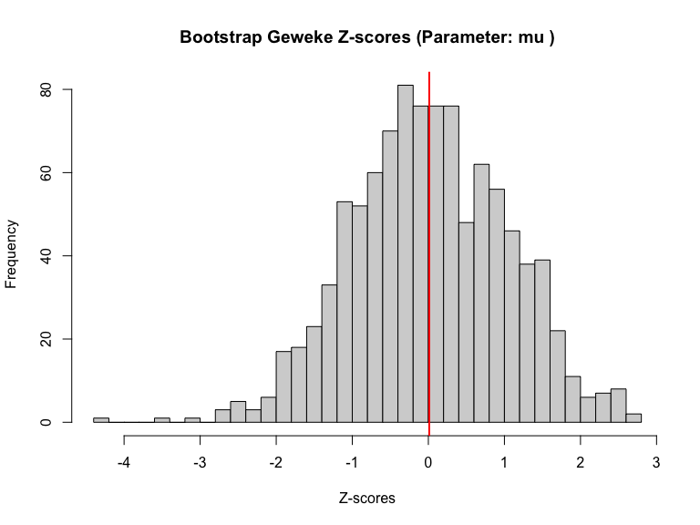

```r
# Plot the Z-scores for the first parameter (mu)
plot(result, param = 1)
```

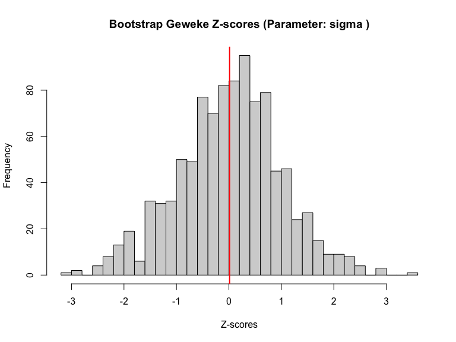

```r
# Plot the Z-scores for the second parameter (sigma)
plot(result, param = 2)
```

## Summary the Z-scores statistic

The `summary()` method for `bootGeweke` objects allow you to summaries the statistics of Z-scores distribution: `Mean Z-score`, `Standard Deviation`, `Confidence Intervals`.

```r
# Summary of the results
summary(result)
```

```
#> Bootstrap Geweke Diagnostic Summary:
#>
#> Parameter: mu
#>   Mean Z-score:            0.01170507
#>   Standard Deviation:      1.027106
#>   Confidence Intervals:    -1.937411 to 1.935605
#>
#> Parameter: sigma
#>   Mean Z-score:            0.01272357
#>   Standard Deviation:      0.9840909
#>   Confidence Intervals:    -2.026007 to 1.960899
```

## Handling Input Erros

The function includes several input checks to ensure valid inputs. For example:

```r
# Invalid input type
tryCatch({
  bootstrap_geweke("invalid_input")
}, error = function(e) {
  print(e)
})
```

```
#> <simpleError in bootstrap_geweke("invalid_input"): Input MCMC data must be an mcmc.list object.>
```

## Assessing MCMC convergence by other tools and comaring resul

```r
# Combined all 3 chains from the previous example into one chain
mcmc_chains <- mcmc.list(mcmc_chain1, mcmc_chain2, mcmc_chain3)
# Use geweke.diag function to compute Z-score
coda::geweke.diag(mcmc_chains)
```

```
#> [[1]]
#>
#> Fraction in 1st window = 0.1
#> Fraction in 2nd window = 0.5
#>
#>     mu  sigma
#> -1.008 -1.456
#>
#>
#> [[2]]
#>
#> Fraction in 1st window = 0.1
#> Fraction in 2nd window = 0.5
#>
#>     mu  sigma
#> 0.1720 0.5332
#>
#>
#> [[3]]
#>
#> Fraction in 1st window = 0.1
#> Fraction in 2nd window = 0.5
#>
#>       mu    sigma
#> 1.723214 0.008649
```

Use the `geweke.diag` function to compute the Z-score of the chain and compare it with the results from `bootstrap_geweke`. Note that the results from these two methods are not expected to be identical. The `geweke.diag` function computes the Z-score directly from the input MCMC chain, while `bootstrap_geweke` computes the mean of Z-scores derived from bootstrap samples of the input MCMC chain. The comparison is intended for assessing the convergence of the chain rather than for numerical equivalence.

## Conclusion

The `bootstrap_geweke()` function provides an effective way to perform a bootstrap-based Geweke diagnostic on MCMC chains. It allows users to compute confidence intervals for Z-scores, improving the interpretation of convergence diagnostics in MCMC simulations.